Tie Ma  
tudent number 1537905  
class 439  
homework 2

```r
#some of the package may not been used in this homework
library("ggplot2")
library("fpp2")
library("glmnet")
library("tidyr")
library("lmtest")
library("boot")
```

# Exercise 1

1. Based upon your estimated trend model, construct a point forecast for 2018Q4.

0.51 + 2.30 * 2018.75 = 4643.635

The point forecast for 2018Q4 is 4643.635

2. Based upon your estimated trend model, construct an interval forecast for 2018Q4.  
   the point forecating is 4643.635.  
   the upper bond is.  
   4643.635 + 4 = 4647.635.  
   the lower bond is.  
   643.635 - 4 = 4639.635.

# Exercise 2

2-a I will assign dumy variable as following

$x_1$ = 1 if the month equal to the January, February and March, otherwise equal to zero. $x_2$ = 1 if the month equal to the April, May and June, otherwise equal to zero. $x_3$ = 1 if the month equal to the July，August，September， otherwise equal to zero

2-b

# Exercise 3

#3-a Estimate a linear model with seasonal dummies as predictors using data from 1990Q1 to 2004Q4. Evaluate the residuals. Compute the AIC and BIC.

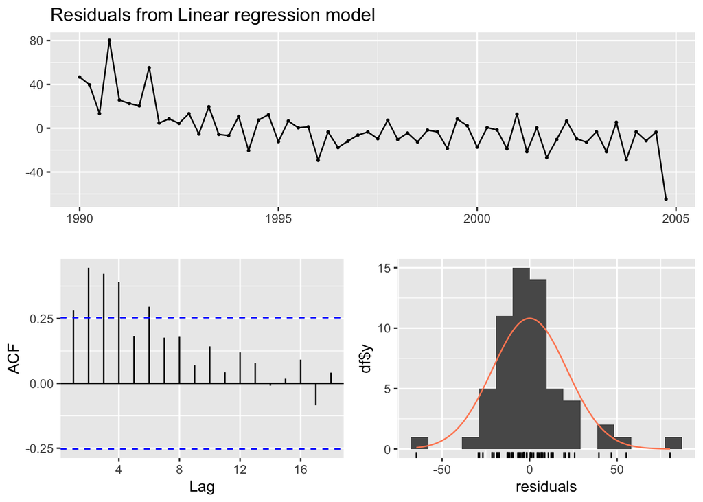

```
##
##  Breusch-Godfrey test for serial correlation of order up to 8
##
## data:  Residuals from Linear regression model
## LM test = 24.961, df = 8, p-value = 0.001578
```

```r
au_beer <- window(ausbeer, start = 1990, end = c(2004,4))
fit.beer_season <- tslm(au_beer ~ season)

#### Evaluate the residuals
checkresiduals(fit.beer_season)
```

According to the ACF and other residuals graphy, we could find the residual is normally distribution butF the residuals are autocorrelated which menas missed the important variable.

```r
CV(fit.beer_season)
```

```
##          CV         AIC        AICc         BIC       AdjR2
## 516.7933673 376.5794425 377.6905536 387.0511653   0.8110164
```

```r
AIC(fit.beer_season)
```

```
## [1] 546.8521
```

```r
BIC(fit.beer_season)
```

```
## [1] 557.3238
```

2. Estimate a linear model with a trend and seasonal dummies as predictors using data from 1990Q1 to 2004Q4. Evaluate the residuals. Compute the AIC and BIC.

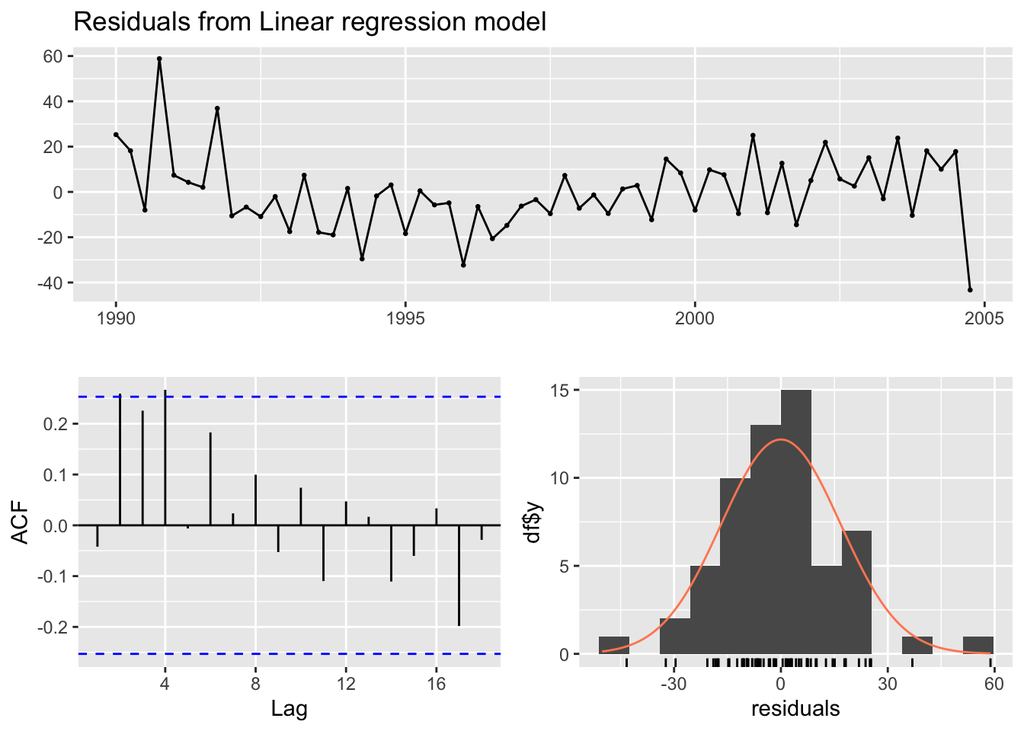

```
##
##  Breusch-Godfrey test for serial correlation of order up to 8
##
## data:  Residuals from Linear regression model
## LM test = 16.727, df = 8, p-value = 0.03308
```

```r
au_beer <- window(ausbeer, start = 1990, end = c(2004,4))
fit.beer_season_trend <- tslm(au_beer ~ season + trend)
checkresiduals(fit.beer_season_trend)
```

```r
CV(fit.beer_season_trend)
```

```
##          CV         AIC        AICc         BIC       AdjR2
## 335.6861880 349.0750922 350.6599978 361.6411595   0.8823235
```

```r
AIC(fit.beer_season_trend)
```

```
## [1] 519.3477
```

```r
BIC(fit.beer_season_trend)
```

```
## [1] 531.9138
```

3. Which model is preferred? Explain.

irst of all, comparing the AIC/BIC, the linear regression model with both season and trend are better due to low AIC and BIC.  
second of all, by checking the residuals, the linear regression model with both season and trend residuals are less autocorrelated and residuals do not seem to have a visible trend.

3-d Evaluate the predictive performance of these models in the test set 2005Q1 to 2009Q4. Which model performs better?

```r
test_set <- window(ausbeer, start = 2005, end = c(2009,4))
evil_model_one <- forecast(fit.beer_season_trend)
evil_model_two <- forecast(fit.beer_season)
accuracy(evil_model_one, test_set)
```

```
##                         ME     RMSE      MAE       MPE     MAPE      MASE
## Training set -1.776357e-15 16.59264 12.49218 -0.117834 2.792942 0.8106167
## Test set      1.206762e+01 16.80038 14.55452  2.984183 3.499996 0.9444419
##                     ACF1 Theil's U
## Training set -0.04212879        NA
## Test set     -0.51518506 0.3360352
```

```r
accuracy(evil_model_two, test_set)
```

```
##                         ME     RMSE      MAE        MPE     MAPE      MASE
## Training set  1.894781e-15 21.21755 14.56444 -0.1973919 3.192709 0.9450856
## Test set     -1.486667e+01 18.68071 15.18667 -3.4198192 3.499224 0.9854616
##                    ACF1 Theil's U
## Training set  0.2810504        NA
## Test set     -0.4723262 0.3651066
```

by comparing two models’ RMSE and MAE we could find that the evil_model_one, which is the linear regression with both season and trend has a smaller number of RMSE and MAE. Therefore the linear regression model with bot season and trend performs better.

# Exercise 4

Q4-a Plot the data and ﬁnd the regression model for Demandwith temperature as an explanatory variable. Why is there a positive relationship?

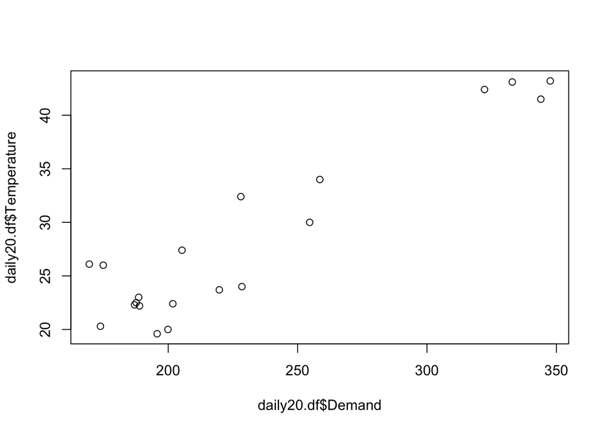

```r
daily20 <- head(elecdaily,20)

#plot the data
daily20.df <- daily20 %>% as.data.frame()
plot(daily20.df$Demand, daily20.df$Temperature)
```

```r
#find the regression model
model_one <- tslm(Demand ~Temperature, data = daily20)
```

Because when the temperature is higher than the comfortable range, people will turn to use an air conditioner to cool down the temperature.

Q4-b: Produce a residual plot. Is the model adequate? Are there any outliers or inﬂuential observations?

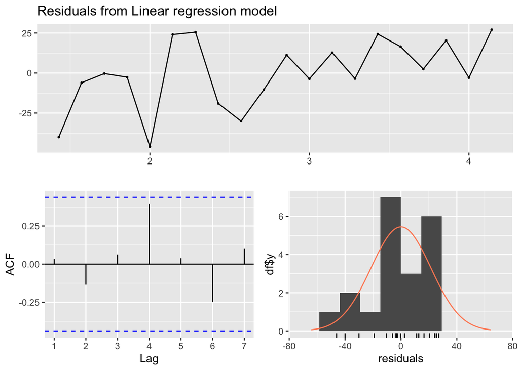

```
##
##  Breusch-Godfrey test for serial correlation of order up to 5
##
## data:  Residuals from Linear regression model
## LM test = 3.8079, df = 5, p-value = 0.5774
```

```r
checkresiduals(model_one)
```

Q4-c Use the model to forecast the electricity demand that you would expect for the next day if the maximum temperature was 15 ◦ and compare it with the forecast if the with maximum temperature was 35 Do you believe these forecasts?

```r
pure_evil <- data.frame(
  Temperature = c(35, 45)
)
daily_forecast_model <- forecast(model_one, newdata = pure_evil)
print(daily_forecast_model)
```

```
##          Point Forecast    Lo 80    Hi 80    Lo 95    Hi 95
## 4.285714       275.7146 245.2278 306.2014 227.5706 323.8586
## 4.428571       343.2868 310.3597 376.2140 291.2890 395.2846
```

Q4-d: Give prediction intervals for your forecasts.

```r
(306.2014 - 245.2278)/2
```

```
## [1] 30.4868
```

When the temperature was 35 degree, the prediction intervals for 95% prediction interval is

```r
(323.8586 - 227.5706)/2
```

```
## [1] 48.144
```

4-e. Plot Demand vs Temperature for all of the available data in elecdaily. What does this say about your model?

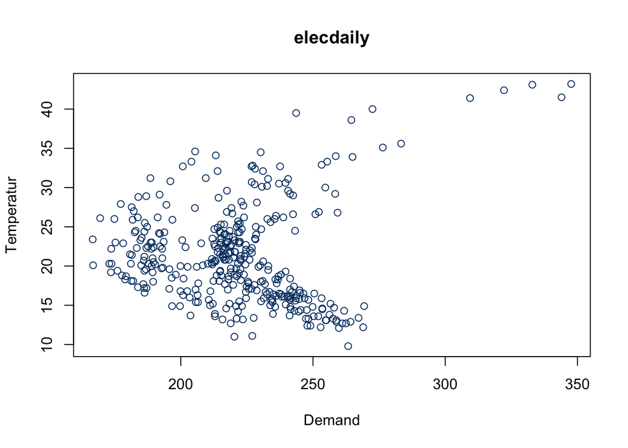

```r
evil_data <-  head(elecdaily, 365)
evil_data.df <- evil_data %>% as.data.frame()
plot(evil_data.df$Demand,evil_data.df$Temperatur, xlab = "Demand", ylab = "Temperatur", main = "elecdaily", col = "#003b6f")
```

# Exercise 5 (R)

1. Plot the data and comment on its features.

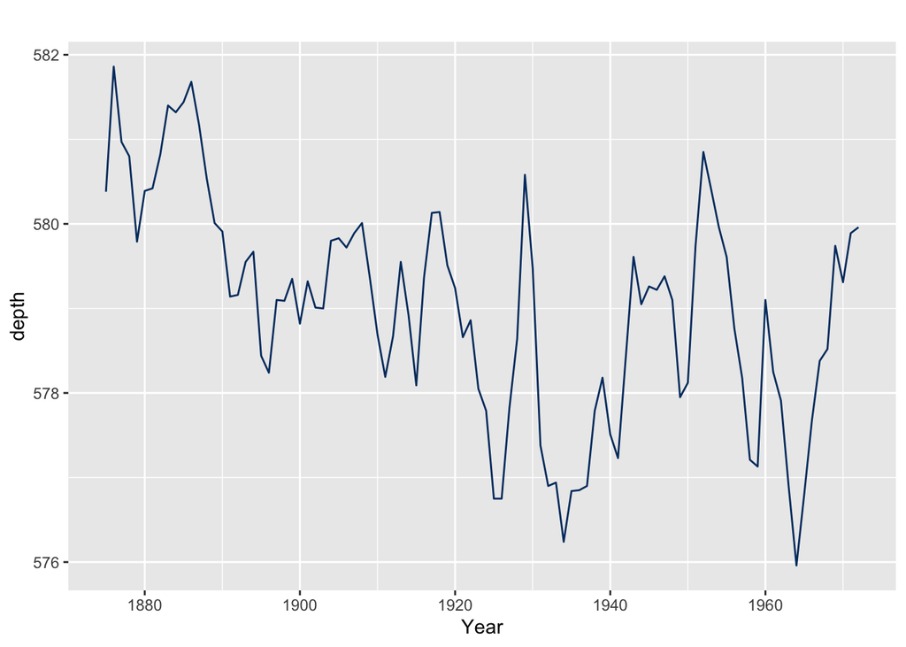

```r
library(datasets)
library(forecast)
Huron<- window(LakeHuron, start=1875, end=1972)
autoplot(Huron, col = "#003b6f") + xlab("Year") + ylab("depth")
```

we could find both downward and cyclic patterns of the water’s depth from graph.

5-b:Fit a linear regression and compare this to a piecewise linear trend model with a knot at 1915.

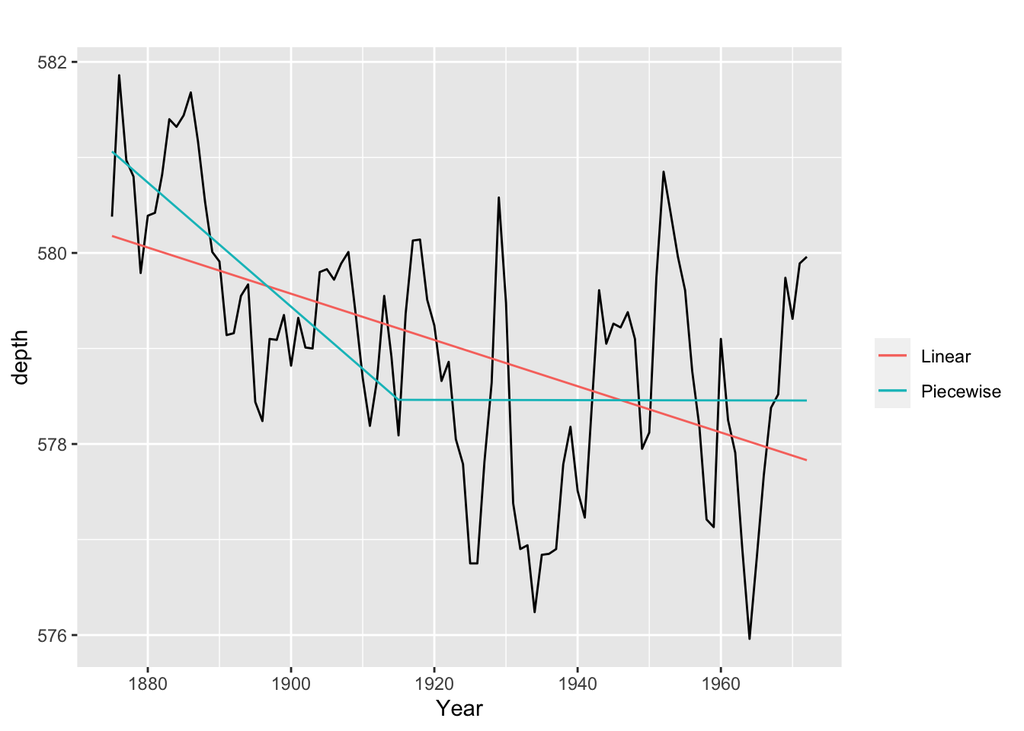

```r
#take of the year as the variale.
Huron<- window(LakeHuron, start=1875, end=1972)
year <- time(Huron)
#fit a linear regression
linear_regression_model <- tslm(Huron ~ year, data = Huron)

#fit a piecewise linear trend
t.break1 <- 1915
t <- time(LakeHuron)
t1 <- ts(pmax(0, t-t.break1), start = 1915)
piecewise_linear_trend <- tslm(LakeHuron ~ t + t1)

autoplot(Huron) +
  autolayer(fitted(linear_regression_model), series = "Linear") +
  autolayer(fitted(piecewise_linear_trend), series = "Piecewise") +
  xlab("Year") +  ylab("depth") +
  guides(colour = guide_legend(title = " "))
```

3. Generate forecasts from these two models for the period up to 1980 and comment on these.

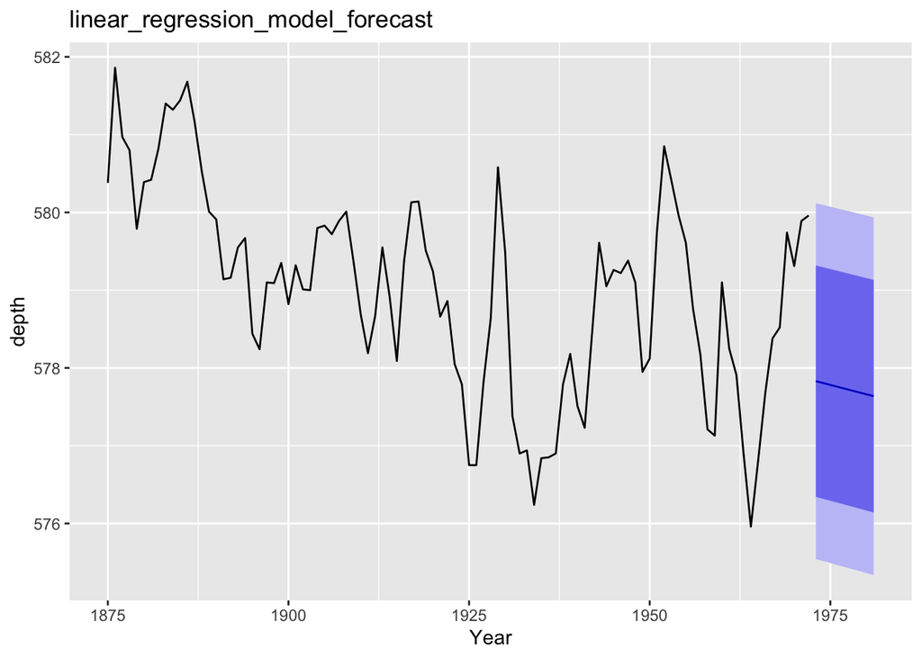

```r
new_data_q5<- data.frame(
  year = c(1972:1980)
)
linear_regression_model_forecast <- forecast(linear_regression_model, newdata = new_data_q5)

t.new <- t[length(t)] + seq(9)
t1.new <- t1[length(t1)] + seq(9)
newdata_evil<- data.frame("t" = t.new, "t1" = t1.new)
piecewise_linear_trend_forecast <- forecast(piecewise_linear_trend, newdata = newdata_evil)

autoplot(linear_regression_model_forecast, xlab = "Year", ylab = "depth", main = "linear_regression_model_forecast")
```

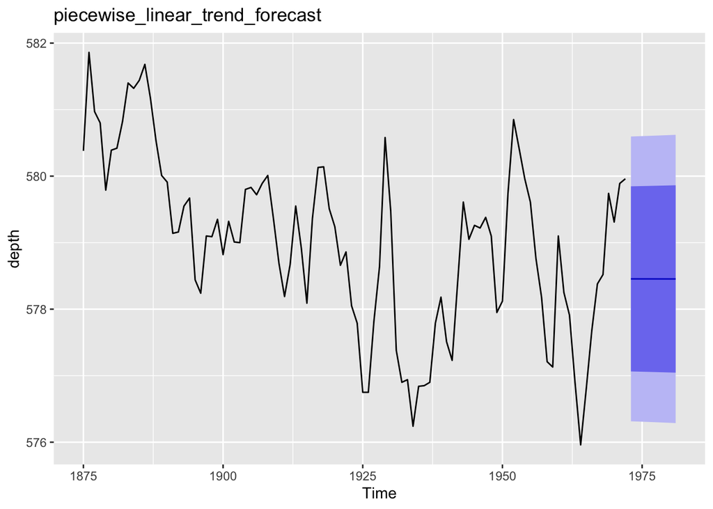

```r
autoplot(piecewise_linear_trend_forecast, series = "Piecewise", lab = "Year", ylab = "depth", main = "piecewise_linear_trend_forecast")
```

```r
rm(list = ls())
```

the linear regression model is forecasting there will be a downturn the piecewise forecasting are hold constand or a littlbe it upward turn.

5-d Repeat b. and c. with a knot at 1920 and comment on any diﬀerences.

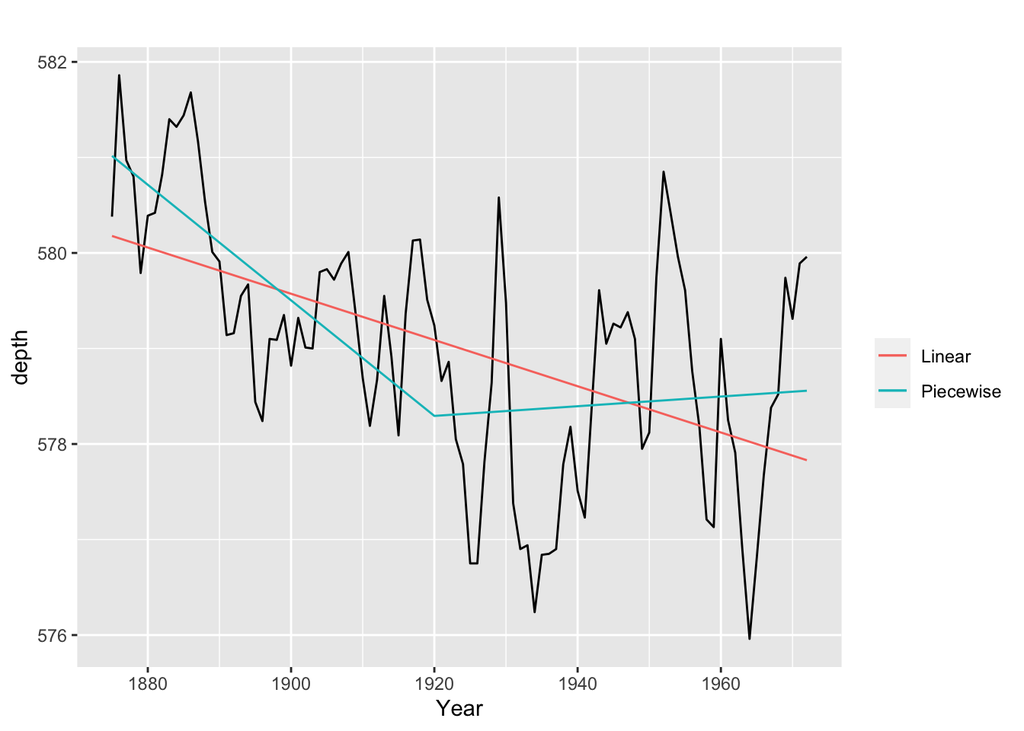

```r
rm(list = ls())
Huron<- window(LakeHuron, start=1875, end=1972)
year <- time(Huron)
linear_regression_model <- tslm(Huron ~ year, data = Huron)
t.break1 <- 1920
t <- time(LakeHuron)
t1 <- ts(pmax(0, t-t.break1), start = 1915)
piecewise_linear_trend <- tslm(LakeHuron ~ t + t1)
autoplot(Huron) +
  autolayer(fitted(linear_regression_model), series = "Linear") +
  autolayer(fitted(piecewise_linear_trend), series = "Piecewise") +
  xlab("Year") +  ylab("depth") +
  guides(colour = guide_legend(title = " "))
```

the linear regression model displays a downward trend the piecewise display a downward trend from 1875 - 1920 and after the time knot, displays an upward trend which is different when the time knot set in 1915.

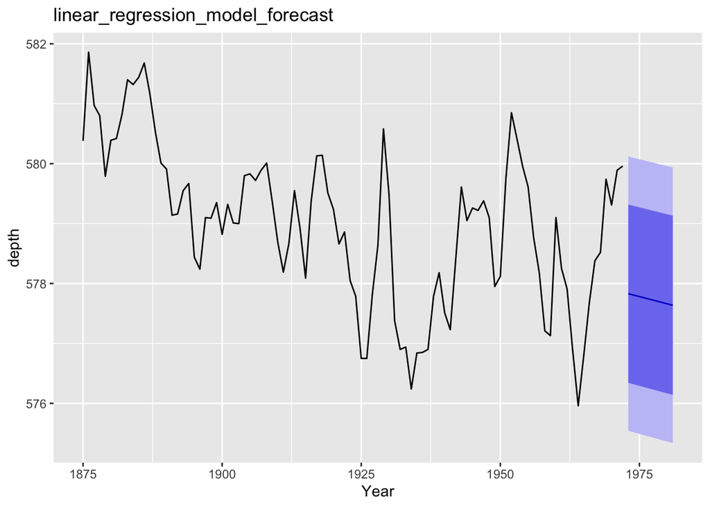

```r
new_data_q5<- data.frame( year = c(1972:1980))
linear_regression_model_forecast <- forecast(linear_regression_model, newdata = new_data_q5)
t.new <- t[length(t)] + seq(9)
t1.new <- t1[length(t1)] + seq(9)
newdata_evil<- data.frame("t" = t.new, "t1" = t1.new)
piecewise_linear_trend_forecast <- forecast(piecewise_linear_trend, newdata = newdata_evil)
autoplot(linear_regression_model_forecast, xlab = "Year", ylab = "depth", main = "linear_regression_model_forecast")
```

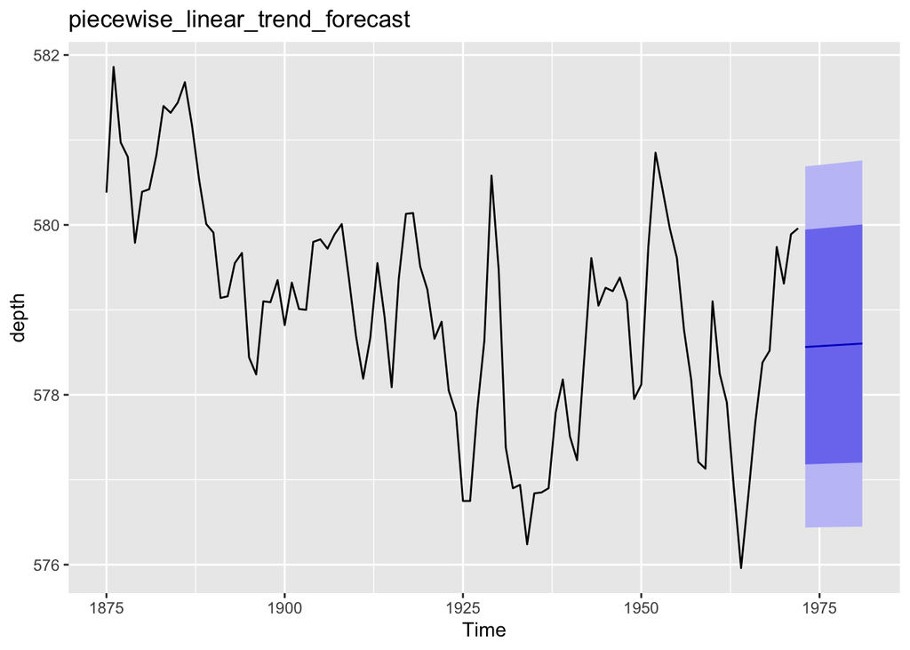

```r
autoplot(piecewise_linear_trend_forecast, series = "Piecewise", lab = "Year", ylab = "depth", main = "piecewise_linear_trend_forecast")
```